# Confidence Intervals (CI) homework

```r
library(tidyverse)
library(janitor)
library(infer)
```

Load the data again, clean_names(), and re-familiarise yourself with it.

Investigate the distribution of lot_area. Is the distribution roughly normal? If not, what problems do you find?

```r
names(clean_ames)
```

```
 [1] "order"           "pid"             "ms_sub_class"    "ms_zoning"
 [5] "lot_frontage"    "lot_area"        "street"          "alley"
 [9] "lot_shape"       "land_contour"    "utilities"       "lot_config"
[13] "land_slope"      "neighborhood"    "condition_1"     "condition_2"
[17] "bldg_type"       "house_style"     "overall_qual"    "overall_cond"
[21] "year_built"      "year_remod_add"  "roof_style"      "roof_matl"
[25] "exterior_1st"    "exterior_2nd"    "mas_vnr_type"    "mas_vnr_area"
[29] "exter_qual"      "exter_cond"      "foundation"      "bsmt_qual"
[33] "bsmt_cond"       "bsmt_exposure"   "bsmt_fin_type_1" "bsmt_fin_sf_1"
[37] "bsmt_fin_type_2" "bsmt_fin_sf_2"   "bsmt_unf_sf"     "total_bsmt_sf"
[41] "heating"         "heating_qc"      "central_air"     "electrical"
[45] "x1st_flr_sf"     "x2nd_flr_sf"     "low_qual_fin_sf" "gr_liv_area"
[49] "bsmt_full_bath"  "bsmt_half_bath"  "full_bath"       "half_bath"
[53] "bedroom_abv_gr"  "kitchen_abv_gr"  "kitchen_qual"    "tot_rms_abv_grd"
[57] "functional"      "fireplaces"      "fireplace_qu"    "garage_type"
[61] "garage_yr_blt"   "garage_finish"   "garage_cars"     "garage_area"
[65] "garage_qual"     "garage_cond"     "paved_drive"     "wood_deck_sf"
[69] "open_porch_sf"   "enclosed_porch"  "x3ssn_porch"     "screen_porch"
[73] "pool_area"       "pool_qc"         "fence"           "misc_feature"
[77] "misc_val"        "mo_sold"         "yr_sold"         "sale_type"
[81] "sale_condition"  "sale_price"
```

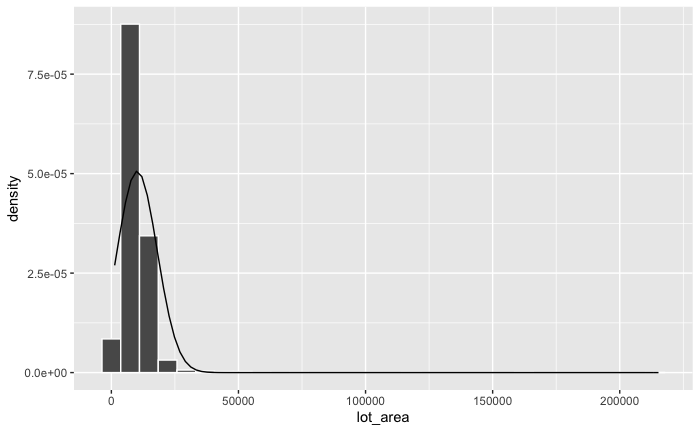

```r
ggplot(clean_ames) +
  aes(x = lot_area)+
  geom_histogram(aes(y = ..density..), col = "White") +
  stat_function(
    fun = dnorm,
    args = list(
      mean = mean(clean_ames$lot_area),
      sd = sd(clean_ames$lot_area)
    )
  )
```

This isn’t a normal distribution, the data is very skewed to the right.

Compute and visualise a bootstrap sampling distribution for the mean(lot_area) of the sold houses.

```r
ames_resample <- clean_ames %>%
  select("lot_area") %>%
  rep_sample_n(size = 293, reps = 10000) %>%
  summarise(average_lot_area = mean(lot_area))
ames_resample
```

| replicate | average_lot_area |
| --- | --- |
| 1 | 11363.495 |
| 2 | 9642.549 |
| 3 | 10685.727 |
| 4 | 10526.273 |
| 5 | 10060.904 |
| 6 | 10945.334 |
| 7 | 10779.215 |
| 8 | 11175.928 |
| 9 | 10294.300 |
| 10 | 10083.024 |

[output cut: 990 more lines]

```r
ci_95 <- ames_resample %>%
  summarise(#mean = mean(average_lot_area),
            lower_bound = quantile(average_lot_area, probs = 0.025),
            upper_bound = quantile(average_lot_area, probs = 0.975))
ci_95
```

| lower_bound | upper_bound |
| --- | --- |
| 9444.635 | 11132.36 |

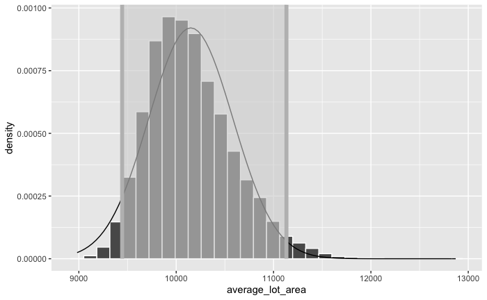

```r
ggplot(ames_resample) +
  aes(x = average_lot_area) +
  geom_histogram(aes(y = ..density..),col = "white", bins = 30) +
  stat_function(fun = dnorm,
                args = list(
                  mean = mean(ames_resample$average_lot_area),
                  sd = sd(ames_resample$average_lot_area)
                  )
                ) +
  shade_confidence_interval(endpoints = ci_95, color = "grey", fill = "lightgrey")
```

```r
NA
NA
```

Then I repeated the same step with stats code.

```r
ames_resample2 <- clean_ames %>%
  select("lot_area") %>%
  specify(response = lot_area) %>%
  generate(reps = 10000, type = "bootstrap") %>%
  calculate(stat = "mean")
ames_resample2
```

| replicate | stat |
| --- | --- |
| 1 | 9942.642 |
| 2 | 10499.538 |
| 3 | 9909.143 |
| 4 | 9889.972 |
| 5 | 10181.625 |
| 6 | 10384.206 |
| 7 | 10157.612 |
| 8 | 10034.754 |
| 9 | 10166.790 |
| 10 | 10203.906 |

[output cut: 990 more lines]

```r
ames_resample2_95_ci <- ames_resample2 %>%
  get_ci(level = 0.95, type = "percentile")
ames_resample2_95_ci
```

| lower_ci | upper_ci |
| --- | --- |
| 9880.442 | 10453.24 |

Use your bootstrap distribution to calculate a 95% CI for mean(lot_area), and visualise it on the distribution.

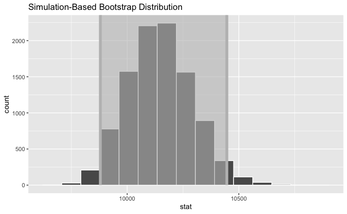

You would like to know the mean(lot_area) of the sold houses with higher confidence. Calculate the 99% CI for this variable (you can re-use your bootstrap distribution from above). Is it narrower or broader than the 95% CI? Does that make sense?

```r
ames_resample2_99_ci <- ames_resample2 %>%
  get_ci(level = 0.99, type = "percentile")
ames_resample2_99_ci
```

| lower_ci | upper_ci |
| --- | --- |
| 9810.147 | 10563.6 |

With 99% CI we get a broader range of lot areas, however it’s not a huge difference. I personally expected a broader range before I ran the test.

Calculate the point estimate of the mean(lot_area)

```r
point_estimate <- ames_resample %>%
  summarise(mean = mean(average_lot_area),
            lower_bound = quantile(average_lot_area, probs = 0.025),
            upper_bound = quantile(average_lot_area, probs = 0.975))
point_estimate
```

[output not shown]

[output not shown]

```r
houses_before_1920_200

houses_before_1920_50000
```

[output not shown]

| lower_ci | upper_ci |
| --- | --- |
| 0.05153584 | 0.06894198 |